# Final Project: R Reference

Matt Fertakos

12/2/2021

# Matt's R Reference Guide

## Loading Data and Packages

### Loading packages library() and require ()

The require() and library() functions load and attach packages to your current workspace.

```r
#Various ways to attach packages
require(palmerpenguins)
library(palmerpenguins)
require(here)
library(here)
```

### here() and read.csv()

The function here() finds your files from the working directory given a path you define. It makes it easier to navigate files contained within folders in your working directory. The read.csv() function reads the csv file specified by the path created using the here() function and creates a data frame from it.

```r
##Load in data and save to an object
ginkgo<-read.csv(here("data","ginkgo_data_2021.csv"))
```

## Data Structures

### c()

The function c() combines or concatenates its arguments into a vector (a 1-dimensional data structure consisting of 1 or more elements).

*All of the elements must be of the same type.* I can’t combine character and numeric types in the same call to c()

```r
##Create a vector of numbers
num_vec  = c(1, 4, 8, 9, 13)

##Create a vector of characters
char_vec = c("a", "fish", "data is cool")
```

### length()

The function length() extracts the length of a factor, vector, or list. It can also be used to define the length of an object from the first to whatever number you define.

```r
##Create a vector of numbers
num_vec  = c(1, 4, 8, 9, 13, 15, 18, 20)

##Get the length of the vector of numbers
length(num_vec)
```

```
## [1] 8
```

```r
##Define the length of the vector
length(num_vec) <- 4
num_vec
```

```
## [1] 1 4 8 9
```

### matrix()

The function matrix() creates a matrix from the set of data you define. The number of rows and number of columns can be defined with the "nrow" and "ncol" arguments within the function.

```r
##Create a vector of numbers
num_vec  = c(1, 4, 8, 9, 13,15,18,20)

##Create a matrix from the vector
matrix = matrix(num_vec, nrow=2, ncol=4)

matrix
```

```
##      [,1] [,2] [,3] [,4]
## [1,]    1    8   13   18
## [2,]    4    9   15   20
```

### data.frame()

The function data.frame() creates a data frame from the set of data you define. The argument row.names can be used to define the row to be used as column names, or set as NULL if there are no column names.

```r
##Create a vector of numbers
num_vec  = c(1, 4, 8, 9, 13,15,18,20)

##Create a data frame from the vector and save it as object 'dataframe'
dataframe = data.frame(num_vec,row.names=NULL)

dataframe
```

```
##   num_vec
## 1       1
## 2       4
## 3       8
## 4       9
## 5      13
## 6      15
## 7      18
## 8      20
```

### nrow ()

The nrow() function returns the number of rows in your object.

```r
##Load required packages
#require('here')
##Load in data
#ginkgo<-read.csv(here("data","ginkgo_data_2021.csv"))
##Count the number of rows in the data
nrow(ginkgo)
```

```
## [1] 756
```

### ncol()

The ncol() function returns the number of columns in your object.

```r
##Load required packages
#require('here')
##Load in the data
#ginkgo<-read.csv(here("data","ginkgo_data_2021.csv"))
##Count the number of columns in the data
ncol(ginkgo)
```

```
## [1] 6
```

### dim()

The dim() function returns the dimensions of an object, or can be used to define the dimensions of an object. The first number in the dim() output is the number of rows, and the second number of the number of columns.

```r
##Get the dimensions of the data
dim(ginkgo)
```

```
## [1] 756   6
```

```r
##Redefine the dimensions of the data
#Below is not run in Rmd file to maintain data structure
#dim(ginkgo)<-c(2,3)
```

## Subsetting

### By name ($)

The $ subsets a data frame by the columns name.

```r
##Pull out the column called "max_width"
ginkgo$max_width
```

```
##   [1]  71.0  64.0  55.0  62.0  65.0  70.0  63.0  56.0  51.0  57.0  59.0  63.0
##  [13]  70.0  50.0  56.0  46.0  54.0  62.0  56.0  55.0  59.0  60.0  63.0  61.0
##  [25]  58.0  55.0  53.0  81.0  94.0  75.0  82.0  86.0  79.0  93.0  88.0  76.0
##  [37]  71.0  91.0  71.0  82.0  65.0  83.0  73.0 102.0  78.0  88.0  81.0  70.0
##  [49]  80.0  96.0  80.0  82.0  86.0  87.0  89.0  69.0  93.0  98.0  81.0  79.0
##  [61]  82.0  85.0  81.0  59.0  53.0  83.0  80.0  77.0  81.0  76.0  82.0  81.0
##  [73]  77.0  68.0  41.0  70.0  68.0  80.0  89.0  90.0  71.0  64.0  55.0  62.0
##  [85]  65.0  70.0  63.0  56.0  51.0  57.0  59.0  63.0  70.0  50.0  56.0  46.0
##  [97]  54.0  62.0  56.0  55.0  59.0  60.0  63.0  61.0  58.0  55.0  53.0  77.0
## [109]  72.0  57.0  75.0  75.0  75.0  67.0  74.0  71.0  72.0  55.0  77.0  97.0
## [121]  73.0  64.0  69.0  92.0  64.0  68.0  53.0  97.0 100.0  90.0  89.0  59.0
## [133]  97.0  76.0  85.0  90.0  87.0  85.0  80.0  86.0  89.0  84.0  88.0  80.0
## [145] 102.0  94.0  95.0 109.0  84.0  68.0  59.0  74.0  70.0  71.0  69.0  74.0
## [157]  70.0  78.0  87.0  69.0  60.0  72.0  59.0  75.0  81.0  82.0  74.0  72.0
## [169]  79.0  84.0  75.0  72.0  88.0  80.0  90.0  58.0  61.0  95.0  72.0  90.0
```

[output cut: 48 more lines]

### By position ([ ])

Square brackets are used following an object to subset by position.

```r
##Select the first row of ginkgo data
ginkgo[,1]
```

```
##   [1]  7719  7719  7719  7719  7719  7719  7719  7719  7719  7719  7719  7719
##  [13]  7719  7719  7719  7719  7719  7719  7719  7719  7719  7719  7719  7719
##  [25]  7719  7719  7719  4847  4847  4847  4847  4847  4847  4847  4847  4847
##  [37]  4847  4847  4847  4847  4847  4847  4847  4847  4847  4847  4847  4847
##  [49]  4847  4847  4847  4847  4847  4874  4874  4874  4874  4874  4874  4874
##  [61]  4874  4874  4874  4874  4874  4874  4874  4874  4874  4874  4873  4873
##  [73]  4873  4873  4873  4873  4873  4873  4873  4873  7719  7719  7719  7719
##  [85]  7719  7719  7719  7719  7719  7719  7719  7719  7719  7719  7719  7719
##  [97]  7719  7719  7719  7719  7719  7719  7719  7719  7719  7719  7719  9603
## [109]  9603  9603  9603  9603  9603  9603  9603  9603  9603  9603  9603  9603
## [121]  9603  9603  9603  3470  3470  3470  3470  3470  3470  3470  3470  3470
## [133]  3470  3470  3470  3470  6719  6720  6722  6723  6725  6726  6727  6728
## [145]  6729  6730  6731  6732 12669 12669 12669 12669 12669 12669 12669 12669
## [157] 12669 12669 12669 12669 12669 12669 12669 12669 12669 12669 12669 12669
## [169] 12669 12669 12669 12669 12669 12669  6721  6721  6721  6721  6721  6721
```

[output cut: 48 more lines]

```r
##Select the element in row 2, column 3
ginkgo[2,3]
```

```
## [1] 64
```

```r
##Select the 3rd column of the ginkgo data
ginkgo[,3]
```

```
##   [1]  71.0  64.0  55.0  62.0  65.0  70.0  63.0  56.0  51.0  57.0  59.0  63.0
##  [13]  70.0  50.0  56.0  46.0  54.0  62.0  56.0  55.0  59.0  60.0  63.0  61.0
##  [25]  58.0  55.0  53.0  81.0  94.0  75.0  82.0  86.0  79.0  93.0  88.0  76.0
##  [37]  71.0  91.0  71.0  82.0  65.0  83.0  73.0 102.0  78.0  88.0  81.0  70.0
##  [49]  80.0  96.0  80.0  82.0  86.0  87.0  89.0  69.0  93.0  98.0  81.0  79.0
##  [61]  82.0  85.0  81.0  59.0  53.0  83.0  80.0  77.0  81.0  76.0  82.0  81.0
##  [73]  77.0  68.0  41.0  70.0  68.0  80.0  89.0  90.0  71.0  64.0  55.0  62.0
##  [85]  65.0  70.0  63.0  56.0  51.0  57.0  59.0  63.0  70.0  50.0  56.0  46.0
##  [97]  54.0  62.0  56.0  55.0  59.0  60.0  63.0  61.0  58.0  55.0  53.0  77.0
## [109]  72.0  57.0  75.0  75.0  75.0  67.0  74.0  71.0  72.0  55.0  77.0  97.0
## [121]  73.0  64.0  69.0  92.0  64.0  68.0  53.0  97.0 100.0  90.0  89.0  59.0
## [133]  97.0  76.0  85.0  90.0  87.0  85.0  80.0  86.0  89.0  84.0  88.0  80.0
## [145] 102.0  94.0  95.0 109.0  84.0  68.0  59.0  74.0  70.0  71.0  69.0  74.0
## [157]  70.0  78.0  87.0  69.0  60.0  72.0  59.0  75.0  81.0  82.0  74.0  72.0
## [169]  79.0  84.0  75.0  72.0  88.0  80.0  90.0  58.0  61.0  95.0  72.0  90.0
```

[output cut: 48 more lines]

### subset ()

The subset() function returns a portion of a vector, matrix, or data frame based on the conditions you provide.

```r
##retrieve all the data for Adelie penguins (in the species column) from the peuguins dataset
subset(penguins, species = "Adelie")
```

```
## # A tibble: 344 × 8
##    species island    bill_length_mm bill_depth_mm flipper_length_mm body_mass_g
##    <fct>   <fct>              <dbl>         <dbl>             <int>       <int>
##  1 Adelie  Torgersen           39.1          18.7               181        3750
##  2 Adelie  Torgersen           39.5          17.4               186        3800
##  3 Adelie  Torgersen           40.3          18                 195        3250
##  4 Adelie  Torgersen           NA            NA                  NA          NA
##  5 Adelie  Torgersen           36.7          19.3               193        3450
##  6 Adelie  Torgersen           39.3          20.6               190        3650
##  7 Adelie  Torgersen           38.9          17.8               181        3625
##  8 Adelie  Torgersen           39.2          19.6               195        4675
##  9 Adelie  Torgersen           34.1          18.1               193        3475
## 10 Adelie  Torgersen           42            20.2               190        4250
## # … with 334 more rows, and 2 more variables: sex <fct>, year <int>
```

## Numerical Data Exploration

### summary()

The summary() function outputs a variety of statistics calculated using the object, or subset of the object inputted.

```r
summary(ginkgo$petiole_length)
```

```
##    Min. 1st Qu.  Median    Mean 3rd Qu.    Max.    NA's
##    8.00   34.00   47.00   48.25   60.00  113.00       4
```

### mean ()

The mean() function finds the average (mean) of the data within an object, or a subset of the object.

```r
##find the mean petiole length in the ginkgo dataset (remove NAs)
mean(ginkgo$petiole_length,na.rm=TRUE)
```

```
## [1] 48.2515
```

### sd()

The sd() function finds the standard deviation of the data within an object, or a subset of the object.

```r
##find the standard deviation of petiole length in the ginkgo dataset (remove NAs)
sd(ginkgo$petiole_length,na.rm = TRUE)
```

```
## [1] 18.58855
```

## Graphical Data Exploration

### plot()

The plot() function creates a scatterplot of two variables (x and y) in a dataset. The arguments that can be included are:

- col=
  - change the color of what is plotted
- pch=
  - change the symbol plotted
- cex=
  - change the plotted text size relative to the base size (1)
- main=
  - create a title for the plot
- xlab=
  - create a title for the x-axis
- ylab=
  - create a title for the y-axis
- xlim=
  - set the limits of the x-axis
- ylim=
  - set the limits of the y-axis

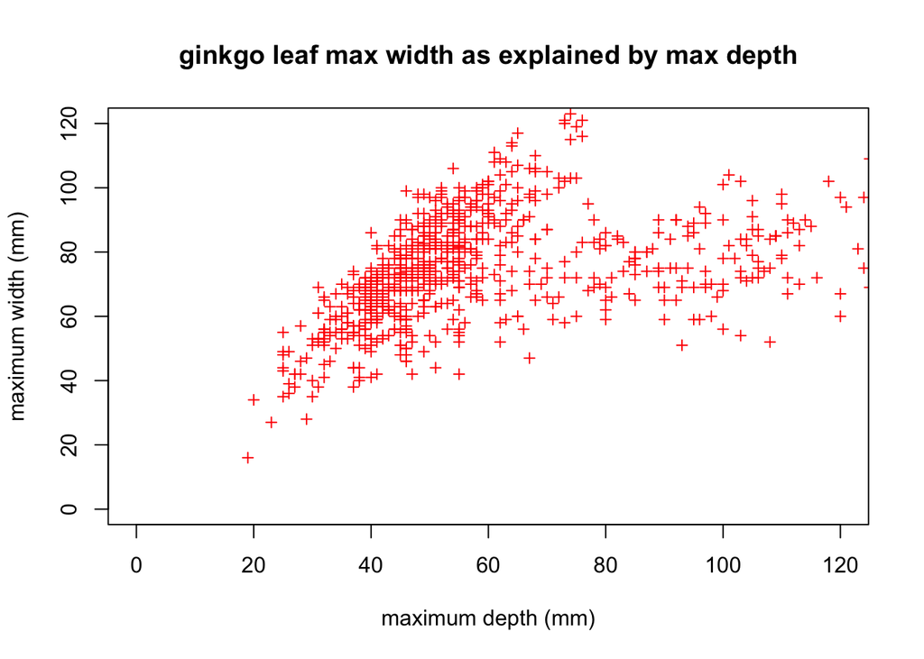

```r
## Create scatterplot, with x and y axes limited to 120
plot(x=ginkgo$max_depth,y=ginkgo$max_width,col="red",pch=3, cex= 0.75, main="ginkgo leaf max width as explained by max depth",xlab="maximum depth (mm)",ylab="maximum width (mm)",xlim=c(0,120),ylim=c(0,120))
```

### hist()

The hist() function creates a histogram of an inputed variable. *The "breaks=" argument creates the number of bars in the graph. It should be noted that inputting a single number here is taken as a suggestion only.

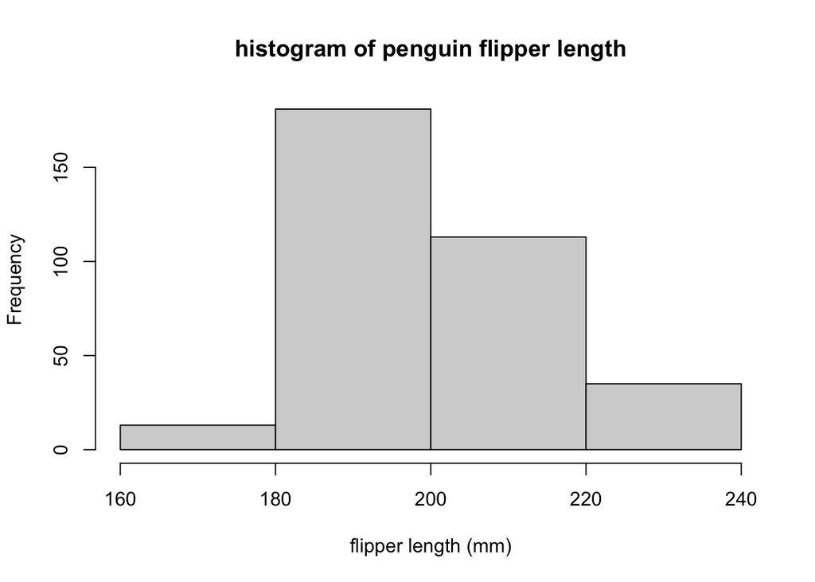

```r
## Create a histogram of penguin flipper lengths with 4 bars.
hist(penguins$flipper_length_mm,breaks=4,main="histogram of penguin flipper length",xlab="flipper length (mm)")
```

### boxplot()

The boxplot() function creates a box-and-whisker plot of an inputted dataset, or subset of a dataset.

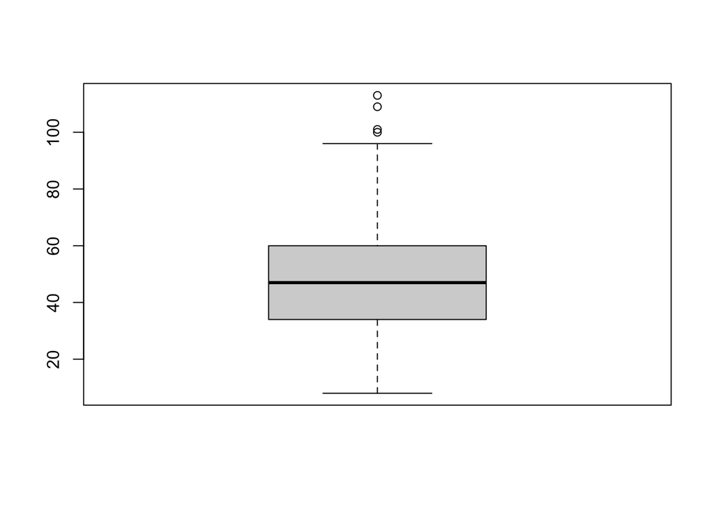

```r
##Create a simple boxplot of ginkgo petiole lengths
boxplot(ginkgo$petiole_length)
```

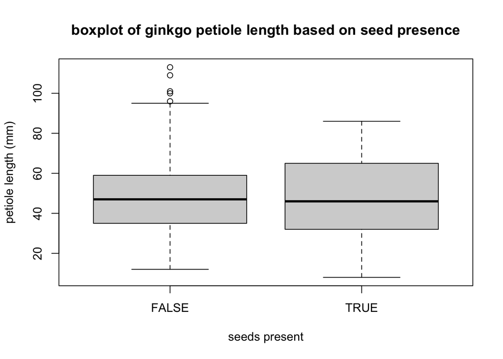

```r
##Create a conditional boxplot of petiole lengths conditioned by if seeds are present
boxplot(petiole_length~seeds_present,data=ginkgo,ylab="petiole length (mm)",xlab="seeds present",main="boxplot of ginkgo petiole length based on seed presence")
```

### par()

The par() function is used to specificy the dimensions of a multi graphic figure.

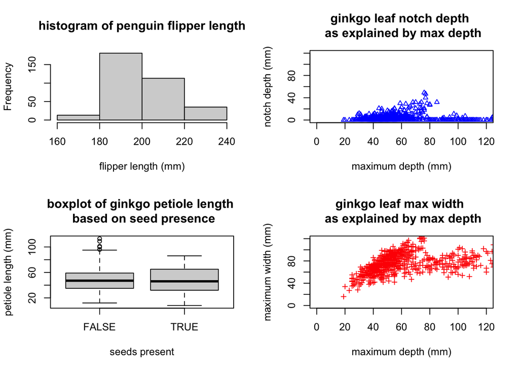

```r
##define dimensions of plots included
par(mfrow=c(2,2))
##plot
hist(penguins$flipper_length_mm,breaks=4,main="histogram of penguin flipper length",xlab="flipper length (mm)")
plot(x=ginkgo$max_depth,y=ginkgo$notch_depth,col="blue",pch=2, cex= 0.75, main="ginkgo leaf notch depth \n as explained by max depth",xlab="maximum depth (mm)",ylab="notch depth (mm)",xlim=c(0,120),ylim=c(0,120))
boxplot(petiole_length~seeds_present,data=ginkgo,ylab="petiole length (mm)",xlab="seeds present",main="boxplot of ginkgo petiole length \n based on seed presence")
plot(x=ginkgo$max_depth,y=ginkgo$max_width,col="red",pch=3, cex= 0.75, main="ginkgo leaf max width \n as explained by max depth",xlab="maximum depth (mm)",ylab="maximum width (mm)",xlim=c(0,120),ylim=c(0,120))
```

## Distribution Functions

### dnorm()

The dnorm() function returns a value of the probability density function for the normal distribution based on a specific value (x), as well as mean (mean), and standard deviation (sd) values inputted. This is otherwise known as the probability an event occurs.

```r
##Find the value of the standard normal distribution with a mean of 0 and standard deviation of 1 at x=2.
dnorm(x=2,mean=0,sd=1)
```

```
## [1] 0.05399097
```

### pnorm()

The pnorm() function returns the value of the cumulative density function with inputs q, mean, and sd. The output is equivalent to a %. Result would be the same as adding up all the outputs of dnorm() individually for different x values.

```r
##Find the percentage of females shorter than 60 inches in a population with mean = 65 and standard deviation = 2
pnorm(q=65,mean=65,sd=2)
```

```
## [1] 0.5
```

### qnorm()

The qnorm() function, otherwise known as the quantile function, is the inverse of the pnorm() function. It is used to determine the Z-score of the xth quantile of the normal distribution. Uses % (like 75% quantile) to determine the actual value where that quantile lies in the distribution.

```r
##What is the 99th quantile of a normal distribution (aka Z score)?
qnorm(0.99,mean=0,sd=1)
```

```
## [1] 2.326348
```

### dbinom()

The dbinom() function returns the value of the probability density function for a binomally distributed dataset. Arguments inputed include x, size, and prob. Output is the probability an event occurs in a binomally distributed dataset.

```r
##What is the probability of 8 successes during 15 trials where the probability of success on each trial is 0.8?
dbinom(x=8,size=15,prob=0.8)
```

```
## [1] 0.01381906
```

### pbinom()

The pbinom() function returns the value of the cumulative density function with inputs q, size, and prob of a binomally distributed dataset. The output is equivalent to a %. Result would be the same as adding up all the outputs of dbinom() individually for different x values.

```r
##What is the probability of getting less than 10 successes in 20 trials where the probability of success on each trial is 75%?
pbinom(q=10,size=20,p=0.75)
```

```
## [1] 0.01386442
```

### qbinom()

The qbinom() function, otherwise known as the quantile function, is the inverse of the pbinom() function. It is used to determine the Z-score of the xth quantile of the binomial distribution. Uses % (like 75% quantile) to determine the actual value where that quantile lies in the distribution.

```r
##What is the 75th quantile of a binomial distribution with 50 trials and probability of success on each trial of 60%?
qbinom(0.75,size=50,prob=0.60)
```

```
## [1] 32
```